# Bases de datos

Clase 3 - Tablas de frecuencias

01/11/2019

En esta clase vamos a profundizar el tratamiento de bases de datos y vamos a hacer énfasis en las creación de tablas.

Para ello, vamos a trabajar con los datos de la Encuesta de Actividades de Niños, Niñas y Adolescentes (EANNA) 2016-2017. La EANNA es una encuesta que tiene por objetivo medir el trabajo infantil, tomando una definición amplia del mismo:

- Actividades para el mercado
- Actividades de autoconsumo
- Actividades domésticas intensivas

En particular, vamos a trabajar con la base de datos del dominio urbano de niños y niñas de 5 a 15 años.

#### Librerías necesarias para la la clase

Cargamos las librerías necesarias para realizar este ejercicio

```r
library(haven)
library(tidyverse, warn = FALSE)
library(openxlsx, warn = FALSE)
library(dplyr)
library(plyr)
library(eph)
library(questionr)
# library(foreign)
```

#### Base de datos de la EANNA

En primer lugar, cargamos nuestra base de datos y la filtramos para trabajar únicamente con los niños y niñas respondentes de 5 a 15 años, de manera de poder replicar algunos resultados del capítulo 3 de la publicación.

```r
C3<-read_sav(file = "../Fuentes/C3_EANNA URBANA_03.sav")
```

```r
C3_5a15 <- C3 %>%
  filter(C2_P02<=15 & is.na(NNRSPST_C3))
```

## Elaboración de tablas de frecuencias

El primer gráfico del capítulo 3 de la publicación de la EANNA muestra las actividades de trabajo infantil realizadas por los niños y niñas de 5 a 15 años.

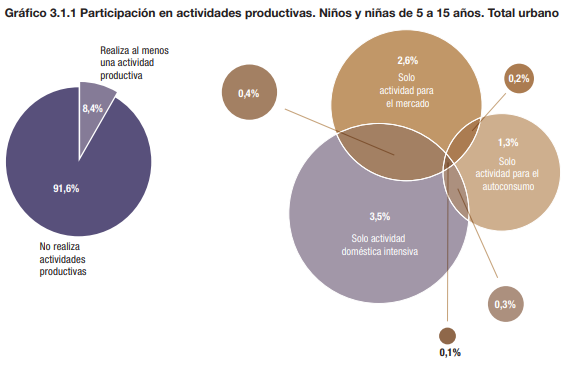

fuente: http://rstudio-pubs-static.s3.amazonaws.com/227171_618ebdce0b9d44f3af65700e833593db.html

Veremos algunas funciones que nos van a permitir replicar los resultados del gráfico y mostrarlos en formato de tabla.

### Tablas de frecuencias simples

Ya vimos en la clase anterior, que para conocer la frecuencia de una variable, podemos usar la función **table()**:

```r
grafico3.1.1_a <- table(C3_5a15$Diagvenn)
grafico3.1.1_a
```

```
    1     2     3     4     5     6     7     8
  362   166   475    33    48    29    12 12370
```

A esa tabla, podemos agregarle los totales con la función **addmargins()**:

```r
addmargins(grafico3.1.1_a,margin = 1)
```

```
    1     2     3     4     5     6     7     8   Sum
  362   166   475    33    48    29    12 12370 13495
```

Si en lugar de querer la frecuencia absoluta, queremos la frecuencia relativa, podemos usar la función **prop.table()**:

```r
prop.table(grafico3.1.1_a)
```

```
           1            2            3            4            5            6            7            8
0.0268247499 0.0123008522 0.0351982216 0.0024453501 0.0035568729 0.0021489441 0.0008892182 0.9166357910
```

Para obtener la frecuencia relativa acumulada, podemos usar la función **cumsum()** junto con **prop.table()**:

```r
cumsum(prop.table(grafico3.1.1_a))
```

```
         1          2          3          4          5          6          7          8
0.02682475 0.03912560 0.07432382 0.07676917 0.08032605 0.08247499 0.08336421 1.00000000
```

Sin embargo, las frecuencias que vimos en las tablas anteriores (tanto las absolutas como las relativas) corresponden a los valores muestrales. Y, en nuestro, caso, nos interesa obtener los valores ponderados.

### Tablas de frecuencias ponderadas

Si quisieramos ponderar nuestros resultados, podemos usar la función **wtd.table()**.

```r
grafico3.1.1_b <- wtd.table(C3_5a15$Diagvenn, weights = C3_5a15$PONDERA)
grafico3.1.1_b
```

```
      1       2       3       4       5       6       7       8
 172100   85485  233928   15660   25566   18969    5201 6047555
```

```r
prop.table(grafico3.1.1_b)
```

```
           1            2            3            4            5            6            7            8
0.0260581328 0.0129435182 0.0354196798 0.0023711235 0.0038710181 0.0028721483 0.0007874977 0.9156768816
```

En cualquiera de estos casos, si quisieramos convertir estas salidas en tablas, podríamos usar la función **data.frame()**. Por ejemplo:

```r
grafico3.1.1_b <- data.frame(prop.table(grafico3.1.1_b))
grafico3.1.1_b
```

| Var1 | Freq |
| --- | --- |
| 1 | 0.0260581328 |
| 2 | 0.0129435182 |
| 3 | 0.0354196798 |
| 4 | 0.0023711235 |
| 5 | 0.0038710181 |
| 6 | 0.0028721483 |
| 7 | 0.0007874977 |
| 8 | 0.9156768816 |

Otra posible solución para obtener el mismo resultado es usar la función **ddply()** de la librería **plyr**.

```r
grafico3.1.1_c<-ddply(C3_5a15,
              "Diagvenn",
              summarise,
              diagvenn_p=sum(PONDERA))
grafico3.1.1_c
```

| Diagvenn | diagvenn_p |
| --- | --- |
| 1 | 172100 |
| 2 | 85485 |
| 3 | 233928 |
| 4 | 15660 |
| 5 | 25566 |
| 6 | 18969 |
| 7 | 5201 |
| 8 | 6047555 |

Para obtener los porcentajes, se puede hacer también creando una nueva variable, con la función **mutate()** que vimos la clase pasada:

```r
grafico3.1.1_c <- grafico3.1.1_c %>%
  mutate(Prop = diagvenn_p/sum(diagvenn_p))
grafico3.1.1_c
```

| Diagvenn | diagvenn_p | Prop |
| --- | --- | --- |
| 1 | 172100 | 0.0260581328 |
| 2 | 85485 | 0.0129435182 |
| 3 | 233928 | 0.0354196798 |
| 4 | 15660 | 0.0023711235 |
| 5 | 25566 | 0.0038710181 |
| 6 | 18969 | 0.0028721483 |
| 7 | 5201 | 0.0007874977 |
| 8 | 6047555 | 0.9156768816 |

Cómo hacer para que los números sean más amigables a simple vista?

La función **round()** sirve para redondear los números especificando la cantidad de los decimales deseados.

```r
grafico3.1.1_c<- grafico3.1.1_c %>%
  mutate(Prop = round((diagvenn_p/sum(diagvenn_p))*100,
                      digits=1))
grafico3.1.1_c
```

| Diagvenn | diagvenn_p | Prop |
| --- | --- | --- |
| 1 | 172100 | 2.6 |
| 2 | 85485 | 1.3 |
| 3 | 233928 | 3.5 |
| 4 | 15660 | 0.2 |
| 5 | 25566 | 0.4 |
| 6 | 18969 | 0.3 |
| 7 | 5201 | 0.1 |
| 8 | 6047555 | 91.6 |

Finalmente, vamos a ver una función que nos permite hacer todo esto de una vez, que corresponde a la librería **eph**. La función es **calculate_tabulates()**.

```r
grafico3.1.1_d <- calculate_tabulates(base= C3_5a15,
                    x="Diagvenn",
                    weights = "PONDERA",
                    add.percentage = "col")
# Si queremos cambiar el nombre de una columna de la tabla:
names(grafico3.1.1_d)[2] <- "total"
data.frame(grafico3.1.1_d)
```

| Diagvenn | total |
| --- | --- |
| 1 | 2.6% |
| 2 | 1.3% |
| 3 | 3.5% |
| 4 | 0.2% |
| 5 | 0.4% |
| 6 | 0.3% |
| 7 | 0.1% |
| 8 | 91.6% |

```r
grafico3.1.1_sexo <- calculate_tabulates(base= C3_5a15,
                    x="Diagvenn",
                    y="C2_P03",
                    weights = "PONDERA",
                    add.percentage = "col")
# Cambiamos los nombres de las columnas de la tabla:
names(grafico3.1.1_sexo)[2] <- "varon"
names(grafico3.1.1_sexo)[3] <- "mujer"
data.frame(grafico3.1.1_sexo)
```

| Diagvenn.C2_P03 | varon | mujer |
| --- | --- | --- |
| 1 | 3.2% | 2.0% |
| 2 | 2.0% | 0.5% |
| 3 | 2.7% | 4.4% |
| 4 | 0.4% | 0.0% |
| 5 | 0.3% | 0.5% |
| 6 | 0.5% | 0.1% |
| 7 | 0.1% | 0.0% |
| 8 | 90.7% | 92.5% |

Podríamos juntar estas dos tablas, simplemente pegando una al lado de la otra, para que nos quede en un mismo cuadro la información del total, de los varones y de las mujeres. Para eso vamos a usar la función **cbind()**, que permite combinar dos tablas que tienen la misma cantidad de filas.

Una vez que las combinamos, deberíamos para ello sacar la columna que indica el tipo de trabajao infantil (Diagnvenn) para que no se repita.

```r
grafico3.1.1_total <- cbind(grafico3.1.1_d,grafico3.1.1_sexo) %>%
  select(-3)
grafico3.1.1_total
```

| Diagvenn | total | varon | mujer |
| --- | --- | --- | --- |
| 1 | 2.6% | 3.2% | 2.0% |
| 2 | 1.3% | 2.0% | 0.5% |
| 3 | 3.5% | 2.7% | 4.4% |
| 4 | 0.2% | 0.4% | 0.0% |
| 5 | 0.4% | 0.3% | 0.5% |
| 6 | 0.3% | 0.5% | 0.1% |
| 7 | 0.1% | 0.1% | 0.0% |
| 8 | 91.6% | 90.7% | 92.5% |

Vamos con otro ejemplo, ahora con el cuadro 3.1.1. Este cuadro nos muestra información similar al anterior, donde se muestra el trabajo para el mercado, para el autoconsumo y la actividad doméstica intensiva, pero, en este caso, para el cálculo de la incidencia se contabiliza el total de niños y niñas que realizaron cada actividad, sin importar si la hicieron junto con otras actividades. Esto implica que las categorías usadas en este cuadro no son excluyentes, y por lo tanto, las variables para el cálculo de cada una de ellas son diferentes y deben trabajarse por separado.

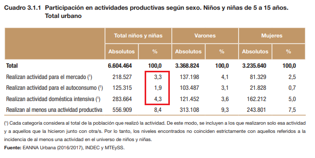

fuente: http://rstudio-pubs-static.s3.amazonaws.com/227171_618ebdce0b9d44f3af65700e833593db.html

Nos vamos a concentrar en la frecuencia relativa del total de niños y niñas, de las actividades para el mercado, autoconsumo y doméstica intensiva.

**Actividades para el mercado**

```r
cuadro3.1.1_a <- calculate_tabulates(base= C3_5a15,
                    x="Mercado",
                    weights = "PONDERA",
                    add.percentage = "col")
#Convertimos la salida en un dataframe:
cuadro3.1.1_a <- data.frame(cuadro3.1.1_a)
cuadro3.1.1_a
```

| Mercado | Freq |
| --- | --- |
| 0 | 96.7% |
| 1 | 3.3% |

```r
#Cambiamos las filas por nombres de columnas:
cuadro3.1.1_a <-spread(cuadro3.1.1_a,
                       key = "Mercado",
                       value = Freq)
#Le ponemos nombre a la fila para saber que corresponde a trabajo en el mercado:
rownames(cuadro3.1.1_a) <- "Mercado"
cuadro3.1.1_a
```

|  | 0 | 1 |
| --- | --- | --- |
| Mercado | 96.7% | 3.3% |

**Actividades para el autoconsumo**

```r
cuadro3.1.1_b <- calculate_tabulates(base= C3_5a15,
                    x="Autoconsumo",
                    weights = "PONDERA",
                    add.percentage = "col")
#Convertimos la salida en un dataframe:
cuadro3.1.1_b <- data.frame(cuadro3.1.1_b)
cuadro3.1.1_b
```

| Autoconsumo | Freq |
| --- | --- |
| 0 | 98.1% |
| 1 | 1.9% |

```r
#Cambiamos las filas por nombres de columnas:
cuadro3.1.1_b <-spread(cuadro3.1.1_b,
                       key = "Autoconsumo",
                       value = Freq)
#Le ponemos nombre a la fila para saber que corresponde a trabajo de autoconsumo:
rownames(cuadro3.1.1_b) <- "Autoconsumo"
cuadro3.1.1_b
```

|  | 0 | 1 |
| --- | --- | --- |
| Autoconsumo | 98.1% | 1.9% |

**Actividades domesticas intensivas**

```r
cuadro3.1.1_c <- calculate_tabulates(base= C3_5a15,
                    x="Domestica",
                    weights = "PONDERA",
                    add.percentage = "col")
#Convertimos la salida en un dataframe:
cuadro3.1.1_c <- data.frame(cuadro3.1.1_c)
cuadro3.1.1_c
```

| Domestica | Freq |
| --- | --- |
| 0 | 95.7% |
| 1 | 4.3% |

```r
#Cambiamos las filas por nombres de columnas:
cuadro3.1.1_c <-spread(cuadro3.1.1_c,
                       key = "Domestica",
                       value = Freq)
#Le ponemos nombre a la fila para saber que corresponde a trabajo doméstico intensivo:
rownames(cuadro3.1.1_c) <- "Domestica"
cuadro3.1.1_c
```

|  | 0 | 1 |
| --- | --- | --- |
| Domestica | 95.7% | 4.3% |

```r
cuadro3.1.1 <- rbind(cuadro3.1.1_a,cuadro3.1.1_b,cuadro3.1.1_c)
cuadro3.1.1
```

|  | 0 | 1 |
| --- | --- | --- |
| Mercado | 96.7% | 3.3% |
| Autoconsumo | 98.1% | 1.9% |
| Domestica | 95.7% | 4.3% |

Para una visualización más clara, podemos cambiar los nombres de las columnas de la tabla con **colnames()**:

```r
colnames(cuadro3.1.1) <- c("No trabajo","Trabajo")
cuadro3.1.1
```

|  | No trabajo | Trabajo |
| --- | --- | --- |
| Mercado | 96.7% | 3.3% |
| Autoconsumo | 98.1% | 1.9% |
| Domestica | 95.7% | 4.3% |

Finalmente, para replicar exactamente la información del cuadro que propusimos al inicio, nos falta eliminar los datos de la columna “No trabajo”.

[output not shown]

## Exportación de bases de datos o tablas

La función **write.xlsx** de la libreria *openxlsx* nos permite exportar dataframes a un archivo excel. Cabe aclarar que existen numerosas funciones y librerías alternativas para exportar resultados a un excel. En este caso, optamos por *openxlsx* ya que resulta una de las más sencillas para exportar rapidamente los resultados. Otras librerías permiten también dar formato a las tablas que se exportan, definir si deseamos sobreescribir archivos en caso de que ya existan, etc.

```r
write.xlsx(grafico3.1.1_total,"../Clase 3/Trabajo infantil por sexo.xlsx")
```

En este caso no es la salida más útil para la tabla, pero muchas veces que se exportan bases de datos, se elige este formato.

```r
write.table(cuadro3.1.1, file="../Clase 3/Trabajo infantil.xls", sep="\t", row.names = T, col.names = T)
```